# Image Compression Results

# Image 4

## Original image

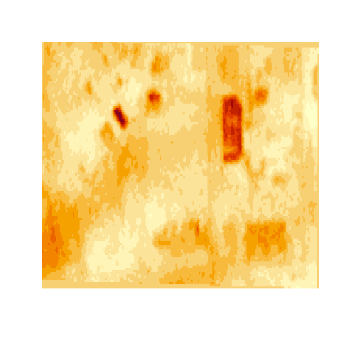

## Image Approximations

### k = 1

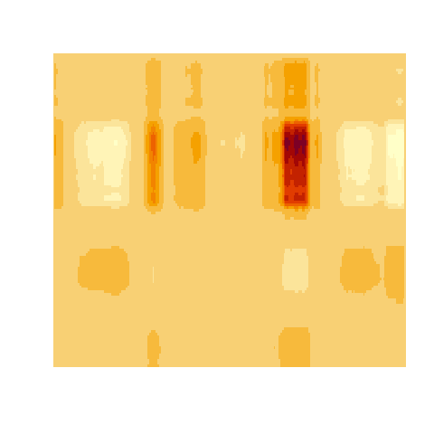

### k = 2

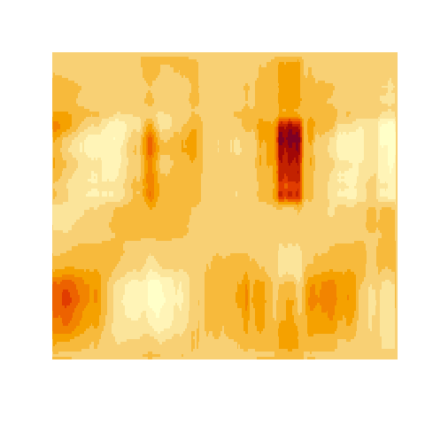

### k = 3

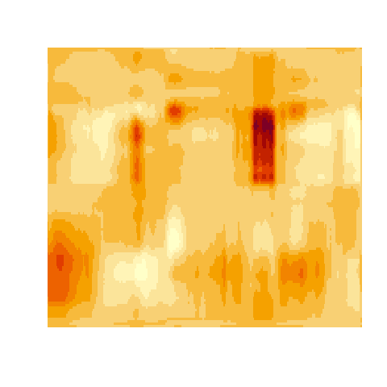

### k = 4

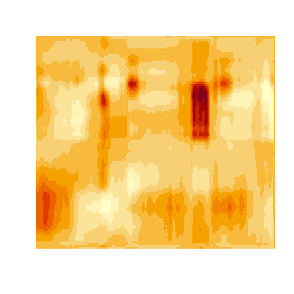

### k = 5

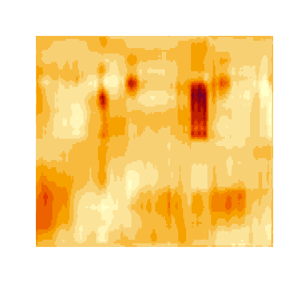

### k = 6

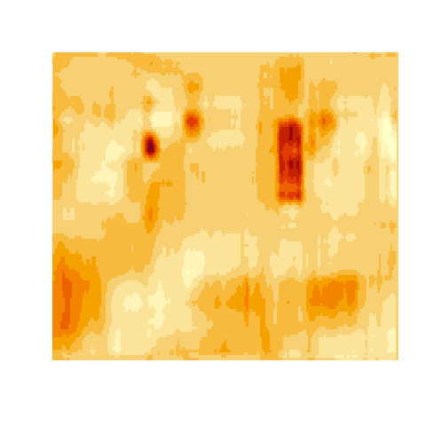

### k = 7

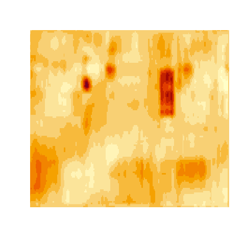

### k = 8

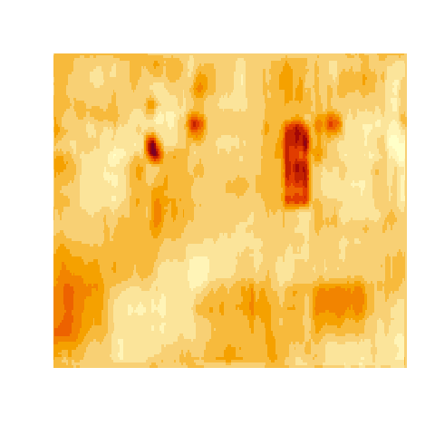

### k = 9

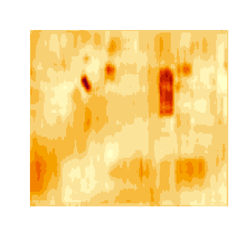

### k = 10

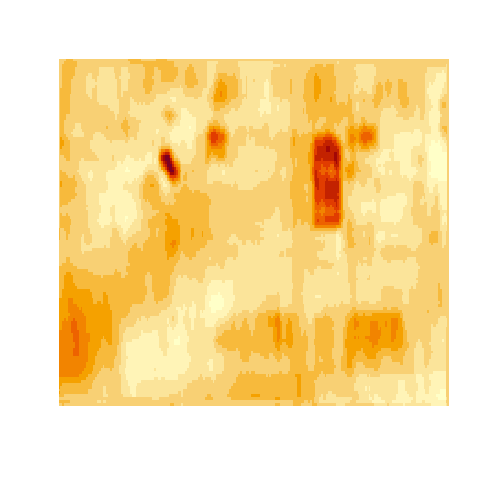

The image approximation seems sufficiently good at k = 4, the original image has little details besides the few blobs with that approximation onwards captures.

## K vs. Error plot

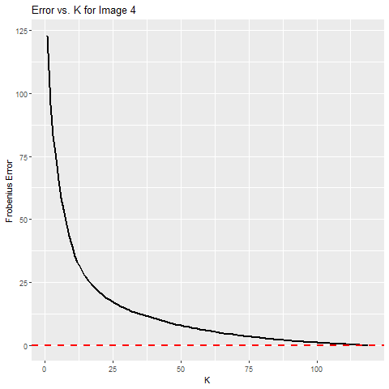

## 1st Eigenvector and PC Score plots

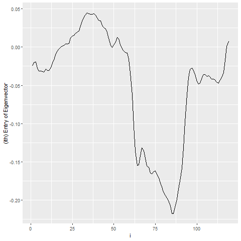

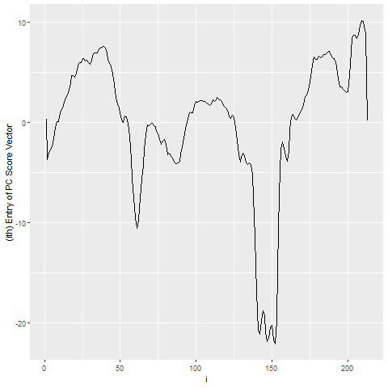

The eigenvector plot displays a single, large dip around indices 60-90, which may correspond with the red spot around that same area of the image. The PC plot also shows a dip around a similar region, as well as another smaller dip after index 50. These two dips probably correspond with the two colored spots in the image.